# Red Bayesiana Multinomial aplicada a Encuesta INEGI: Limpieza y Selección.

### Limpieza de datos y recolección de variables relevantes.

Se mandan a llamar las librerías readr, dplyr y tidyr, relevantes y críticas para la lectura y manejo de archivos csv.

```r
#Si se necesita, instalarlos de la siguiente manera:
#install.packages("readr")
#install.packages("dplyr")
#install.packages("tidyr")
library(readr)
library(dplyr)
library(tidyr)
```

### A través del catálogo y diccionario de datos, y su modelo relacional, proporcionado por INEGI, decidimos cuáles serían las variables relevantes para nuestro análisis.

#### Query 1 - Vértiz

Del archivo tvivienda.csv:

p1_1 - Cantidad de personas en una vivienda.

Del archivo tviaje.csv:

p5_14_05 - Usó el Metro.

p5_14_08 - Usó el Autobús.

#### Query 2 - Sancho

Del archivo tviaje.csv:

p5_6 - Origen del viaje.

p5_11a - Destino del viaje.

p5_14_01 - Utilizó automóvil como medio de transporte

p5_9_1, p5_9_2, p5_10_1, p5_10_2 - Duración del viaje (En hora que inició, minuto que inició, hora que finalizó, minuto que finalizó, respectivamente.)

#### Query 3 - August

Del archivo tviaje.csv:

estrato - Estrato de la persona.

#### Query 4 - Govea

Del archivo tsdem.csv:

niv - Nivel de estudios

Del archivo ttransporte.csv:

p5_14 - Usó Transporte Público.

Del archivo tviaje.csv:

p5_11_a - Destino del viaje.

### Seleccionamos las variables relevantes para nuestro análisis de cada tabla

```r
cols_viv <- c("id_viv", "p1_1")                                   # tvivienda
cols_hog <- c("id_hog", "id_viv")                                 # thogar
cols_sdem <- c("id_soc", "id_hog", "n_ren", "sexo", "niv")        # tsdem
cols_vje <- c(                                                     # tviaje
  "id_via", "id_soc", "p5_6", "p5_11a", "p5_11_a",
  "p5_14_01", "p5_14_05", "p5_14_08",
  "p5_9_1", "p5_9_2", "p5_10_1", "p5_10_2",
  "estrato"
)
cols_tra <- c("id_via", "p5_14", "p5_3", "n_via") # ttransporte
```

Se renombran las variables, a nombres más manejables y legibles.

```r
viv <- read_csv("tvivienda.csv", col_types = cols(), col_select = any_of(cols_viv)) %>%
  rename(n_personas_vivienda = p1_1)

hog <- read_csv("thogar.csv", col_types = cols(), col_select = any_of(cols_hog))

sdem <- read_csv("tsdem.csv", col_types = cols(), col_select = any_of(cols_sdem)) %>%
  rename(nivel_estudios = niv)

vje <- read_csv("tviaje.csv", col_types = cols(), col_select = any_of(cols_vje)) %>%
  mutate(
    # origen / destino (acepta p5_11a o p5_11_a)
    origen  = .data[["p5_6"]],
    destino = coalesce(.data[["p5_11a"]], .data[["p5_11a"]]),
    uso_auto    = .data[["p5_14_01"]],
    uso_metro   = .data[["p5_14_05"]],
    uso_autobus = .data[["p5_14_08"]],
    dur_horas_i = .data[["p5_9_1"]],
    dur_min_i   = .data[["p5_9_2"]],
    dur_horas_v = .data[["p5_10_1"]],
    dur_min_v   = .data[["p5_10_2"]]
  ) %>%
  select(id_via, id_soc, origen, destino, uso_auto, uso_metro, uso_autobus,
         dur_horas_i, dur_min_i, dur_horas_v, dur_min_v, estrato)

tra <- read_csv("ttransporte.csv", col_types = cols(), col_select = any_of(cols_tra)) %>%
  rename(transporte_publico = p5_14)
```

Dado el modelo relacional proporcionado por INEGI:

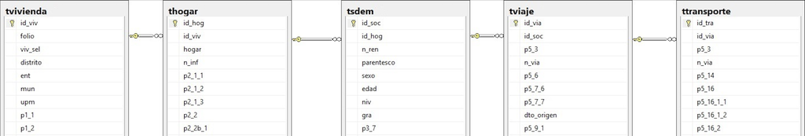

Relizamos una unión con Left Join (Dado que no queremos perder ningún dato, aún si no hay dato alguno a la tabla a la que unimos).

```r
df <- vje %>%
  left_join(sdem, by = "id_soc") %>%
  left_join(hog,  by = "id_hog") %>%
  left_join(viv,  by = "id_viv") %>%
  left_join(tra,  by = "id_via")
#Partimos desde viaje porque será el más usado en nuestro análisis.
```

Y finalmente seleccionamos solo las variables necesarias ya definidas en un paso anterior.

```r
df_final <- df %>%
  select(
    id_via, id_soc, id_hog, id_viv,
    # Query 1 - Vertiz
    n_personas_vivienda, uso_metro, uso_autobus,
    # Query 2 - Sanchez
    origen, destino, uso_auto, dur_horas_i, dur_min_i, dur_horas_v, dur_min_v,
    # Query 3 - Augusto
    sexo, estrato,
    # Query 4 - Govea
    nivel_estudios, transporte_publico
  )
glimpse(df_final)
```

```
Rows: 890,748
Columns: 18
$ id_via              <dbl> 2936, 2936, 2937, 2937, 2938, 2939, 2940, 2940, 29…
$ id_soc              <dbl> 1268, 1268, 1268, 1268, 1268, 1268, 1269, 1269, 12…
$ id_hog              <dbl> 434, 434, 434, 434, 434, 434, 434, 434, 434, 434, …
$ id_viv              <dbl> 418, 418, 418, 418, 418, 418, 418, 418, 418, 418, …
$ n_personas_vivienda <chr> "03", "03", "03", "03", "03", "03", "03", "03", "0…
$ uso_metro           <dbl> 2, 2, 2, 2, 2, 2, 2, 2, 2, 2, 2, 2, 2, 2, 2, 2, 2,…
$ uso_autobus         <dbl> 2, 2, 2, 2, 2, 2, 2, 2, 2, 2, 2, 2, 2, 2, 2, 2, 2,…
$ origen              <chr> "01", "01", "03", "03", "01", "07", "01", "01", "0…
$ destino             <chr> "03", "03", "01", "01", "07", "01", "03", "03", "0…
$ uso_auto            <dbl> 2, 2, 2, 2, 2, 2, 2, 2, 2, 2, 2, 2, 2, 2, 2, 2, 1,…
$ dur_horas_i         <chr> "08", "08", "14", "14", "17", "23", "08", "08", "1…
$ dur_min_i           <chr> "00", "00", "00", "00", "00", "00", "00", "00", "0…
$ dur_horas_v         <chr> "09", "09", "15", "15", "17", "23", "09", "09", "1…
$ dur_min_v           <chr> "00", "00", "30", "30", "05", "05", "00", "00", "3…
$ sexo                <dbl> 2, 2, 2, 2, 2, 2, 2, 2, 2, 2, 2, 2, 2, 2, 1, 1, 1,…
$ estrato             <dbl> 3, 3, 3, 3, 3, 3, 3, 3, 3, 3, 3, 3, 3, 3, 3, 3, 3,…
$ nivel_estudios      <chr> "07", "07", "07", "07", "07", "07", "06", "06", "0…
$ transporte_publico  <chr> "11", "14", "11", "14", "14", "04", "11", "14", "1…
```

```r
readr::write_csv(df_final, "df_final_r.csv")
```

Se hace el cálculo de la duración del viaje con dur_horas_i, dur_min_i, dur_horas_v y dur_min_v, esto para tener que manejar mejor el tiempo del viaje, dado el query solicitado.

```python
import pandas as pd
df = pd.read_csv("df_final_r.csv")

df["duracion_viaje_min"] = (df["dur_horas_v"]*60 + df["dur_min_v"]) -(df["dur_horas_i"]*60 + df["dur_min_i"])

df = df.drop(columns=["dur_horas_i","dur_min_i","dur_horas_v","dur_min_v"])
df.to_csv("df_final_py.csv", index=False, encoding="utf-8")
```

```r
data <- readr::read_csv("df_final_py.csv")
glimpse(data)
```

```
Rows: 890,748
Columns: 15
$ id_via              <dbl> 2936, 2936, 2937, 2937, 2938, 2939, 2940, 2940, 29…
$ id_soc              <dbl> 1268, 1268, 1268, 1268, 1268, 1268, 1269, 1269, 12…
$ id_hog              <dbl> 434, 434, 434, 434, 434, 434, 434, 434, 434, 434, …
$ id_viv              <dbl> 418, 418, 418, 418, 418, 418, 418, 418, 418, 418, …
$ n_personas_vivienda <dbl> 3, 3, 3, 3, 3, 3, 3, 3, 3, 3, 3, 3, 3, 3, 3, 3, 3,…
$ uso_metro           <dbl> 2, 2, 2, 2, 2, 2, 2, 2, 2, 2, 2, 2, 2, 2, 2, 2, 2,…
$ uso_autobus         <dbl> 2, 2, 2, 2, 2, 2, 2, 2, 2, 2, 2, 2, 2, 2, 2, 2, 2,…
$ origen              <dbl> 1, 1, 3, 3, 1, 7, 1, 1, 3, 3, 1, 1, 9, 9, 1, 2, 1,…
$ destino             <dbl> 3, 3, 1, 1, 7, 1, 3, 3, 1, 1, 9, 9, 1, 1, 2, 1, 6,…
$ uso_auto            <dbl> 2, 2, 2, 2, 2, 2, 2, 2, 2, 2, 2, 2, 2, 2, 2, 2, 1,…
$ sexo                <dbl> 2, 2, 2, 2, 2, 2, 2, 2, 2, 2, 2, 2, 2, 2, 1, 1, 1,…
$ estrato             <dbl> 3, 3, 3, 3, 3, 3, 3, 3, 3, 3, 3, 3, 3, 3, 3, 3, 3,…
$ nivel_estudios      <dbl> 7, 7, 7, 7, 7, 7, 6, 6, 6, 6, 6, 6, 6, 6, 8, 8, 8,…
$ transporte_publico  <dbl> 11, 14, 11, 14, 14, 4, 11, 14, 11, 14, 11, 14, 11,…
$ duracion_viaje_min  <dbl> 60, 60, 90, 90, 5, 5, 60, 60, 90, 90, 45, 45, 45, …
```